# Clustering

Aichinger-Fankhauser Peter

Beyerle Gregor

Reckmeyer Emanuel Elias

Ustaszewski Michael

2021-12-30

## Clustering

For the clustering (no matter whether optics, kmeans, hiearchical), we need to define a strategy to deal with missing values. We decided to take two approaches:

1. drop all records containing missing values,
2. drop the variables containing many missing values (i.e. age-related variables).

Then we can compare both results.

However, some variables will have to be excluded anyway, because they were either used to extract other features or are per se not useful for our purpose.

```r
variables_to_exclude <- c(
  "ID", # no useful information
  "Postcode", # to many attributes
  "MERCHANDISE2015", # merchandise_any might be enough because it is a rare category anyway
  "MERCHANDISE2016",
  "MERCHANDISE2017",
  "MERCHANDISE2018",
  "MERCHANDISE2019",
  "COUNT2015", # expressed in COUNTtotal and COUNTaverage
  "COUNT2016",
  "COUNT2017",
  "COUNT2018",
  "COUNT2019",
  "SUM2015", # expressed in SUMtotal and SUMaverage
  "SUM2016",
  "SUM2017",
  "SUM2018",
  "SUM2019",
  "LastPaymentDate", # expressed in days_since_last_payment,
  "LastPaymentYEAR",
  "Ort", # same as postal code
  "year_born", # expressed in age_at_last_donation
  "LastPaymentMONTH", # expressed in days_since_last_payment
  "PenultimatePaymentMONTH", # expressed in donation_interval
  "PenultimatePaymentYEAR", # expressed in donation_interval
  "age_at_last_donation" # expressed in generation_monikert
)
```

Check remaining features:

```r
customer_segmentation_first_prepro <- get_preprocessed_data(
  "data/customer_segmentation_test.csv",
  "data/PLZ_Verzeichnis-20211201.xlsx"
)

df_without_variables_to_exlude <- customer_segmentation_first_prepro %>%
  select(-all_of(variables_to_exclude))

df_without_variables_to_exlude %>% colnames()
```

```
##  [1] "Gender"                  "Bundesland"
##  [3] "generation_moniker"      "COUNTtotal"
##  [5] "SUMtotal"                "SUMaverage"
##  [7] "COUNTaverage"            "XMAS_donor"
##  [9] "donation_interval"       "days_since_last_payment"
## [11] "merchandise_any"         "num_of_donation_years"
```

```r
# approach a)
df_without_na <- df_without_variables_to_exlude %>% drop_na()
df_without_na %>% nrow() # 242480 cases
```

```
## [1] 242480
```

```r
# approach b)
df_with_fewer_vars <- df_without_variables_to_exlude %>%
  select(-c(generation_moniker, donation_interval)) %>%
  drop_na()

df_with_fewer_vars %>% nrow() # 396694 cases
```

```
## [1] 396694
```

Also, it is necessary to dummy-code nominal variables, and to scale numeric variables.

```r
df_without_na_prep <- df_without_na %>% recipe() %>%
  step_scale(all_numeric()) %>%
  step_dummy(all_nominal()) %>%
  prep() %>%
  bake(new_data = NULL)

df_with_fewer_vars_prep <- df_with_fewer_vars %>% recipe() %>%
  step_scale(all_numeric()) %>%
  step_dummy(all_nominal()) %>%
  prep() %>%
  bake(new_data = NULL)
```

### K-MEANS

**Approach A**

```r
set.seed(123)

max_k = 10

kmeans_clust_a <-
  tibble(k = 1:max_k) %>%
  mutate(
    kclust = map(k, ~kmeans(df_without_na_prep, .x)),
    tidied = map(kclust, tidy),
    glanced = map(kclust, glance),
    augmented = map(kclust, augment, df_without_na_prep)
  )

clusterings_a <-
  kmeans_clust_a %>%
  unnest(cols = c(glanced))
```

**Approach B**

```r
set.seed(123)

max_k = 10

kmeans_clust_b <-
  tibble(k = 1:max_k) %>%
  mutate(
    kclust = map(k, ~kmeans(df_with_fewer_vars_prep, .x)),
    tidied = map(kclust, tidy),
    glanced = map(kclust, glance),
    augmented = map(kclust, augment, df_with_fewer_vars_prep)
  )

clusterings_b <-
  kmeans_clust_b %>%
  unnest(cols = c(glanced))
```

**Choosing optimal number of clusters**

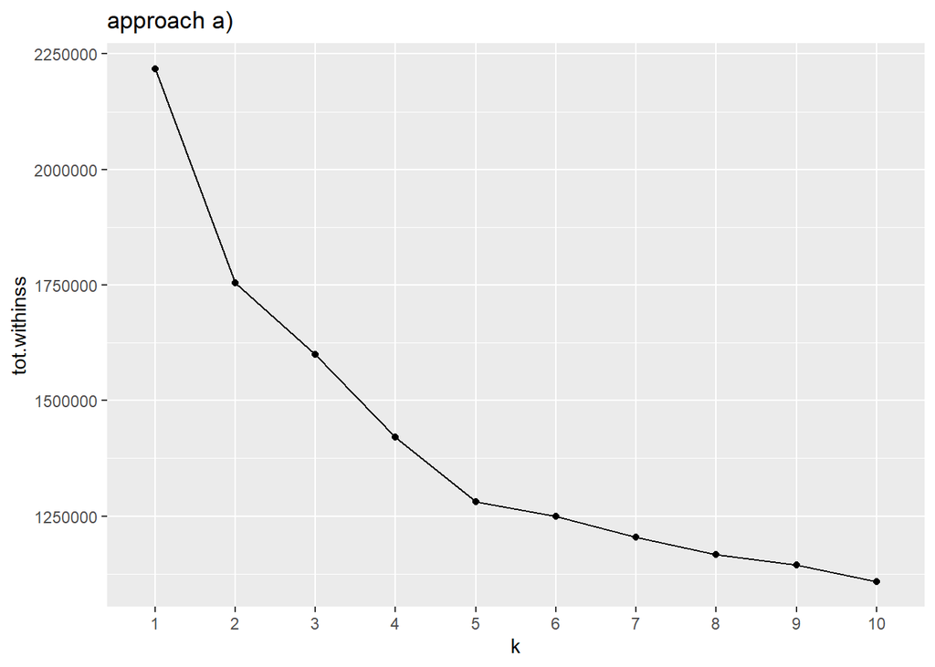

```r
# look at total within sum of squares
ggplot(clusterings_a, aes(k, tot.withinss)) +
  geom_line() +
  geom_point() +
  scale_x_discrete(limits = seq(1:10) %>% as_factor()) +
  labs(title = "approach a)")
```

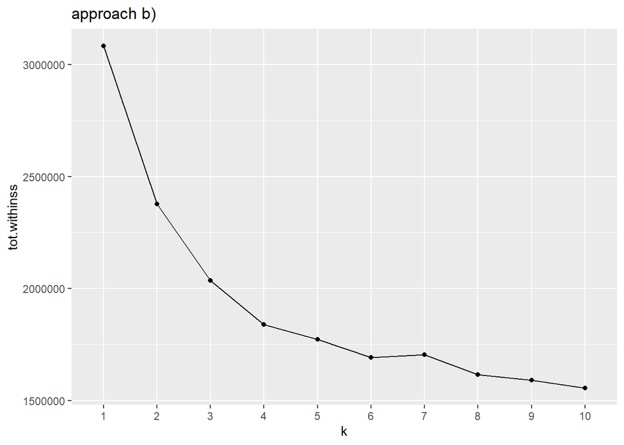

```r
ggplot(clusterings_b, aes(k, tot.withinss)) +
  geom_line() +
  geom_point() +
  scale_x_discrete(limits = seq(1:10) %>% as_factor()) +
  labs(title = "approach b)")
```

According to the elbow method, the above plot suggests that `k=5` is the optimal $k$ for approach a). Using this information, we can cluster the data using `k=5`. For b), `k=4` is the optimal $k$.

```r
kclust_a_k5 <- kmeans(df_without_na_prep, centers = 5)
kclust_b_k4 <- kmeans(df_with_fewer_vars_prep, centers = 4)
```

### Assigning clusters to raw data

```r
kmeans_results_a <- cbind(df_without_na, cluster = kclust_a_k5$cluster) %>%
  select(cluster, everything())

kmeans_results_a %>% head()
```

|  | cluster | Gender | Bundesland | generation_moniker | COUNTtotal | SUMtotal | SUMaverage | COUNTaverage | XMAS_donor | donation_interval | days_since_last_payment | merchandise_any | num_of_donation_years |
| --- | --- | --- | --- | --- | --- | --- | --- | --- | --- | --- | --- | --- | --- |
| 1 | 3 | female | W | silent | 3 | 30.000 | 10.00000 | 0.6 | unlikely | 1585 | -909 | 0 | 2 |
| 2 | 1 | female | W | silent | 3 | 105.000 | 35.00000 | 0.6 | unlikely | 393 | -2061 | 0 | 2 |
| 3 | 1 | female | O | silent | 2 | 7.500 | 3.75000 | 0.4 | unlikely | 1249 | -2402 | 0 | 1 |
| 4 | 4 | female | N | silent | 17 | 213.825 | 12.57794 | 3.4 | unlikely | 43 | -1396 | 0 | 4 |
| 5 | 3 | female | W | silent | 12 | 162.825 | 13.56875 | 2.4 | unlikely | 91 | -1625 | 0 | 3 |
| 6 | 1 | female | W | silent | 4 | 45.000 | 11.25000 | 0.8 | unlikely | 80 | -2422 | 0 | 1 |

```r
kmeans_results_b <- cbind(df_with_fewer_vars, cluster = kclust_b_k4$cluster) %>%
  select(cluster, everything())

kmeans_results_b %>% head()
```

|  | cluster | Gender | Bundesland | COUNTtotal | SUMtotal | SUMaverage | COUNTaverage | XMAS_donor | days_since_last_payment | merchandise_any | num_of_donation_years |
| --- | --- | --- | --- | --- | --- | --- | --- | --- | --- | --- | --- |
| 1 | 2 | female | W | 2 | 45.0 | 22.5 | 0.4 | unlikely | -2418 | 0 | 1 |
| 2 | 4 | female | W | 1 | 15.0 | 15.0 | 0.2 | maybe | -765 | 0 | 1 |
| 3 | 4 | female | W | 1 | 15.0 | 15.0 | 0.2 | maybe | -762 | 0 | 1 |
| 4 | 4 | female | W | 1 | 15.0 | 15.0 | 0.2 | maybe | -743 | 0 | 1 |
| 5 | 4 | female | W | 1 | 22.5 | 22.5 | 0.2 | maybe | -759 | 0 | 1 |
| 6 | 4 | female | W | 1 | 30.0 | 30.0 | 0.2 | unlikely | -807 | 0 | 1 |